# psdv3

## Tell us something new [1 Mark]

Tell us something interesting from the dataset that we have not asked. Anything that intrigues you, anything that might be useful to the policymakers.

The relationship between PM2.5 and PM10 has not been asked in the questions By analyzing the correlation between these pollutants, policymakers can better identify the common sources of pollution and implement more efficient measures targeting both. By knowing the strength of the relationship between PM2.5 and PM10, regulation of industrial emissions, transportation policies, and air quality monitoring can be adjusted to maximize health benefits and environmental improvements.

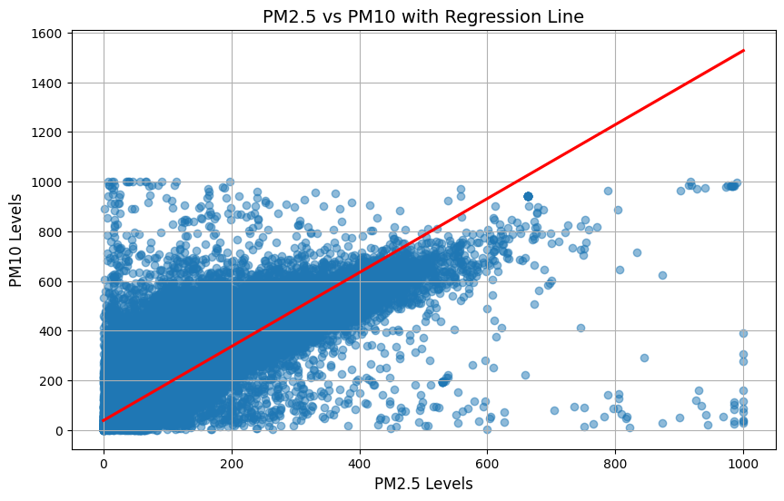

```python
import seaborn as sns

# Scatter plot with a regression line using seaborn
plt.figure(figsize=(10, 6))
sns.regplot(x='PM2.5', y='PM10', data=df, scatter_kws={'alpha':0.5}, line_kws={"color": "red"})

# Adding titles and labels
plt.title('PM2.5 vs PM10 with Regression Line', fontsize=14)
plt.xlabel('PM2.5 Levels', fontsize=12)
plt.ylabel('PM10 Levels', fontsize=12)

# Show plot
plt.grid(True)
plt.show()
```